# Data Mining Project

```r
##Shift 2
#sorted
group_by(shift2,day)%>%summarise(no=sum(n_offenses))%>%arrange(desc(no))
```

```
## # A tibble: 31 × 2
##      day    no
##    <int> <dbl>
## 1     12   177
## 2      7   168
## 3      9   167
## 4      8   157
## 5     14   155
## 6      2   150
## 7     25   149
## 8     15   146
## 9      4   145
## 10    23   143
## # ... with 21 more rows
```

```r
#unsorted
group_by(shift2,day)%>%summarise(no=sum(n_offenses))
```

```
## # A tibble: 31 × 2
##      day    no
##    <int> <dbl>
## 1      1   115
## 2      2   150
## 3      3   134
## 4      4   145
## 5      5   129
## 6      6   128
## 7      7   168
## 8      8   157
## 9      9   167
## 10    10   126
## # ... with 21 more rows
```

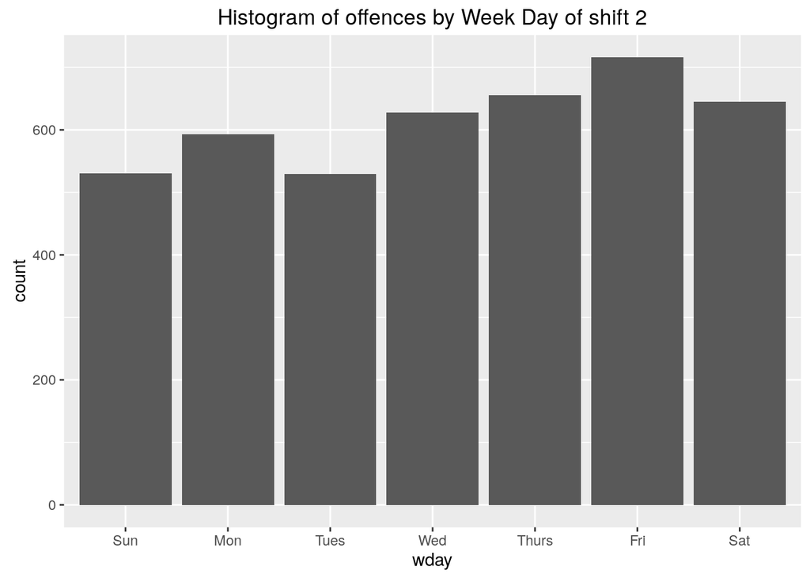

```r
ggplot(shift2,aes(x=wday,weights=n_offenses))+geom_bar() +
  ggtitle('Histogram of offences by Week Day of shift 2')
```

```r
##Shift 3
#sorted
group_by(shift3,day)%>%summarise(no=sum(n_offenses))%>%arrange(desc(no))
```

```
## # A tibble: 31 × 2
##      day    no
##    <int> <dbl>
## 1     20   153
## 2     26   131
## 3     14   121
## 4     18   120
## 5      7   118
## 6     15   116
## 7      3   115
## 8     23   115
## 9     12   113
## 10     2   112
## # ... with 21 more rows
```

```r
#unsorted
group_by(shift3,day)%>%summarise(no=sum(n_offenses))
```

```
## # A tibble: 31 × 2
##      day    no
##    <int> <dbl>
## 1      1    97
## 2      2   112
## 3      3   115
## 4      4    99
## 5      5   105
## 6      6   102
## 7      7   118
## 8      8   106
## 9      9    87
## 10    10    93
## # ... with 21 more rows
```

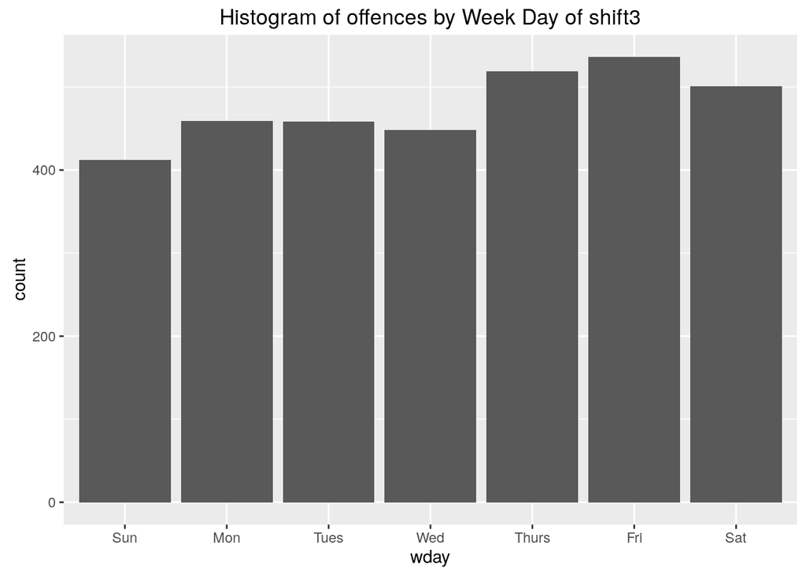

```r
ggplot(shift3,aes(x=wday,weights=n_offenses))+geom_bar() +
  ggtitle('Histogram of offences by Week Day of shift3')
```

How many offenses are occuring per day?

```r
##Information about the days of the month
#sorted
head(group_by(policeData,day)%>%summarise(no=sum(n_offenses))%>%arrange(desc(no)))
```

```
## # A tibble: 6 × 2
##     day    no
##   <int> <dbl>
## 1    12   406
## 2    14   382
## 3    20   382
## 4     7   373
## 5     2   366
## 6    15   360
```

```r
#unsorted
head(group_by(policeData,day)%>%summarise(no=sum(n_offenses)))
```

```
## # A tibble: 6 × 2
##     day    no
##   <int> <dbl>
## 1     1   290
## 2     2   366
## 3     3   333
## 4     4   324
## 5     5   333
## 6     6   315
```

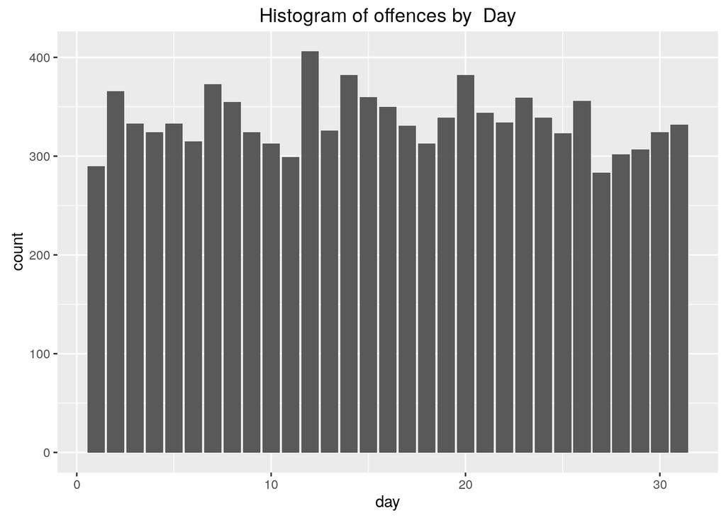

```r
ggplot(policeData,aes(x=day,weights=n_offenses))+geom_bar() +
  ggtitle('Histogram of offences by  Day')
```

```r
##Shift 1
#sorted
head(group_by(shift1,day)%>%summarise(no=sum(n_offenses))%>%arrange(desc(no)))
```

```
## # A tibble: 6 × 2
##     day    no
##   <int> <dbl>
## 1    12    90
## 2    15    86
## 3    21    86
## 4    23    85
## 5    11    84
## 6    14    84
```

```r
#unsorted
head(group_by(shift1,day)%>%summarise(no=sum(n_offenses)))
```

```
## # A tibble: 6 × 2
##     day    no
##   <int> <dbl>
## 1     1    68
## 2     2    81
## 3     3    72
## 4     4    63
## 5     5    82
## 6     6    67
```

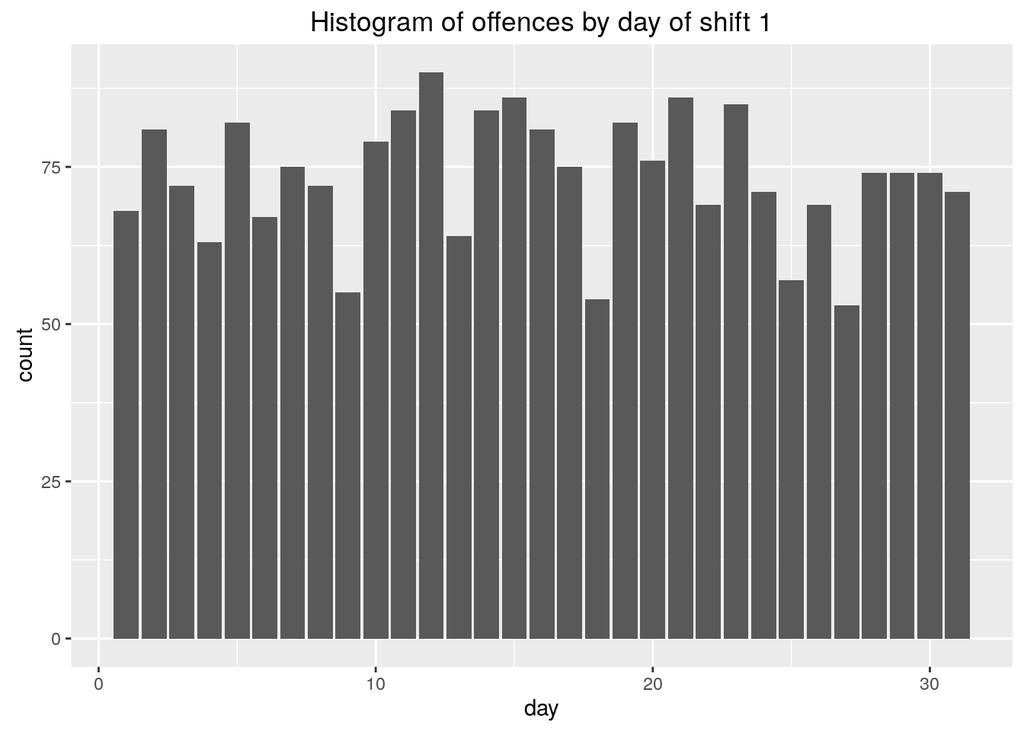

```r
ggplot(shift1,aes(x=day,weights=n_offenses))+geom_bar() +
  ggtitle('Histogram of offences by day of shift 1')
```

```r
##Shift 2
#sorted
head(group_by(shift2,day)%>%summarise(no=sum(n_offenses))%>%arrange(desc(no)))
```

```
## # A tibble: 6 × 2
##     day    no
##   <int> <dbl>
## 1    12   177
## 2     7   168
## 3     9   167
## 4     8   157
## 5    14   155
## 6     2   150
```

```r
#unsorted
head(group_by(shift2,day)%>%summarise(no=sum(n_offenses)))
```

```
## # A tibble: 6 × 2
##     day    no
##   <int> <dbl>
## 1     1   115
## 2     2   150
## 3     3   134
## 4     4   145
## 5     5   129
## 6     6   128
```

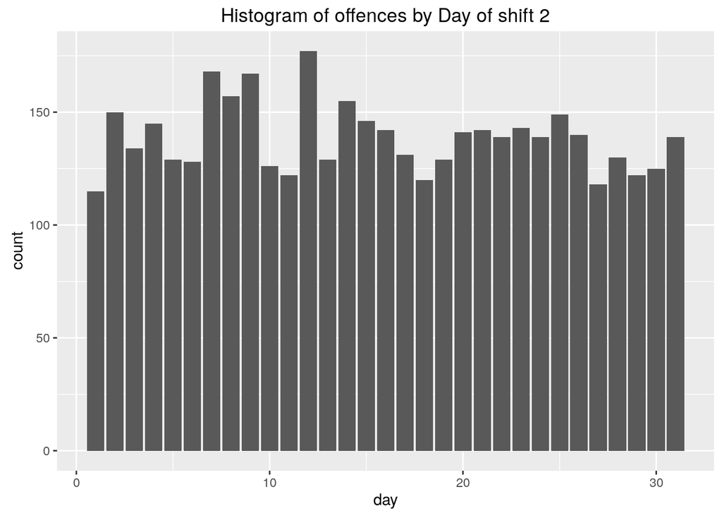

```r
ggplot(shift2,aes(x=day,weights=n_offenses))+geom_bar() +
  ggtitle('Histogram of offences by Day of shift 2')
```

```r
##Shift 3
#sorted
head(group_by(shift3,day)%>%summarise(no=sum(n_offenses))%>%arrange(desc(no)))
```

```
## # A tibble: 6 × 2
##     day    no
##   <int> <dbl>
## 1    20   153
## 2    26   131
## 3    14   121
## 4    18   120
## 5     7   118
## 6    15   116
```

```r
#unsorted
head(group_by(shift3,day)%>%summarise(no=sum(n_offenses)))
```

```
## # A tibble: 6 × 2
##     day    no
##   <int> <dbl>
## 1     1    97
## 2     2   112
## 3     3   115
## 4     4    99
## 5     5   105
## 6     6   102
```

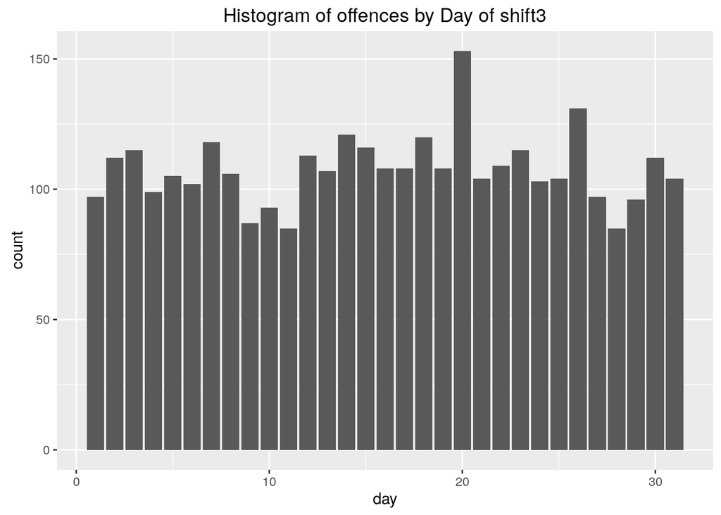

```r
ggplot(shift3,aes(x=day,weights=n_offenses))+geom_bar() +
  ggtitle('Histogram of offences by Day of shift3')
```

Which are the beats with the most offenses? Is there a difference between the shifts?

```r
#Whole day
group_by(policeData, Beat)%>%summarise(sumBeat=sum(n_offenses))%>%arrange(desc(sumBeat))
```

```
## # A tibble: 116 × 2
##     Beat sumBeat
##    <chr>   <dbl>
## 1  12D10     243
## 2   1A20     231
## 3   6B60     227
## 4  17E10     214
## 5  18F20     204
## 6  13D20     200
## 7  19G10     196
## 8   2A50     191
## 9   3B10     185
## 10  1A50     179
## # ... with 106 more rows
```

```r
#shift 1
group_by(shift1, Beat)%>%summarise(sumBeat=sum(n_offenses))%>%arrange(desc(sumBeat))
```

```
## # A tibble: 113 × 2
##     Beat sumBeat
##    <chr>   <dbl>
## 1  17E10      54
## 2  12D10      53
## 3   1A20      50
## 4   6B60      48
## 5  19G10      47
## 6   5F30      45
## 7  13D20      44
## 8  17E40      41
## 9  18F20      41
## 10  2A50      40
## # ... with 103 more rows
```

```r
#shift 2
group_by(shift2, Beat)%>%summarise(sumBeat=sum(n_offenses))%>%arrange(desc(sumBeat))
```

```
## # A tibble: 114 × 2
##     Beat sumBeat
##    <chr>   <dbl>
## 1  18F20      97
## 2   6B60      90
## 3  12D10      88
## 4  19G10      85
## 5   3B10      81
## 6  11H10      80
## 7   1A20      80
## 8  13D20      79
## 9  17E10      78
## 10  2A50      75
## # ... with 104 more rows
```

```r
#shift 3
group_by(shift3, Beat)%>%summarise(sumBeat=sum(n_offenses))%>%arrange(desc(sumBeat))
```

```
## # A tibble: 113 × 2
##     Beat sumBeat
##    <chr>   <dbl>
## 1  12D10      90
## 2   1A20      88
## 3   6B60      82
## 4  17E10      76
## 5  13D20      72
## 6   1A30      69
## 7   2A50      69
## 8   6B50      61
## 9   1A50      59
## 10 18F20      58
## # ... with 103 more rows
```

We can see that the most dangerous beats do not really change during the day. The first places are occupied by the same beats. We can make this analysis also with the least dangerous beats: Which are the beats with the least number of offenses?

```r
#Whole day
group_by(policeData, Beat)%>%summarise(sumBeat=sum(n_offenses))%>%arrange(sumBeat)
```

```
## # A tibble: 116 × 2
##     Beat sumBeat
##    <chr>   <dbl>
## 1  21I30       1
## 2  21I60       1
## 3  21I20       2
## 4  24C40       7
## 5  21I10       8
## 6  23J50       9
## 7  24C60      12
## 8  13D30      13
## 9  24C20      13
## 10 14D50      15
## # ... with 106 more rows
```

```r
#shift 1
group_by(shift1, Beat)%>%summarise(sumBeat=sum(n_offenses))%>%arrange(sumBeat)
```

```
## # A tibble: 113 × 2
##     Beat sumBeat
##    <chr>   <dbl>
## 1  21I30       1
## 2  21I20       2
## 3  12D50       3
## 4  13D30       3
## 5  14D50       3
## 6  18F10       3
## 7   1A40       3
## 8  23J50       3
## 9   7C40       3
## 10  8C20       3
## # ... with 103 more rows
```

```r
#shift 2
group_by(shift2, Beat)%>%summarise(sumBeat=sum(n_offenses))%>%arrange(sumBeat)
```

```
## # A tibble: 114 × 2
##     Beat sumBeat
##    <chr>   <dbl>
## 1  21I60       1
## 2  11H40       2
## 3  23J50       4
## 4  24C20       5
## 5  24C40       5
## 6  24C60       5
## 7  13D30       6
## 8  14D50       6
## 9   1A40       6
## 10 21I10       6
## # ... with 104 more rows
```

```r
#shift 3
group_by(shift3, Beat)%>%summarise(sumBeat=sum(n_offenses))%>%arrange(sumBeat)
```

```
## # A tibble: 113 × 2
##     Beat sumBeat
##    <chr>   <dbl>
## 1  12D50       2
## 2  21I10       2
## 3  23J50       2
## 4  24C40       2
## 5  24C60       2
## 6  24C20       3
## 7  13D30       4
## 8  24C30       5
## 9   9C10       5
## 10 11H50       6
## # ... with 103 more rows
```

Until now, we have just the information how many offenses occured. But interesting is also the type of offense. So we have to do an analysis of the Offense Type. Our focus will be on the day and on the three shifts.

```r
group_by(policeData[!is.na(policeData$Offense_Type),], Offense_Type) %>%
  summarise(counts= sum(n_offenses, na.rm=TRUE)) %>%
  arrange(desc(counts))
```

```
## # A tibble: 7 × 2
##         Offense_Type counts
##                <chr>  <dbl>
## 1              Theft   5705
## 2           Burglary   1893
## 3         Auto Theft   1171
## 4            Robbery    838
## 5 Aggravated Assault    722
## 6               Rape     62
## 7             Murder     25
```

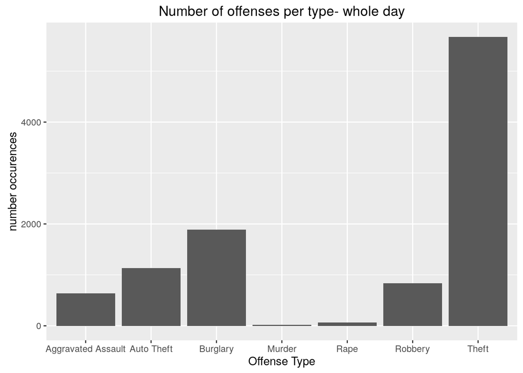

```r
ggplot(policeData, aes(x= policeData$Offense_Type)) +
  geom_bar()+
  ggtitle("Number of offenses per type- whole day")+
  ylab("number occurences")+
  xlab("Offense Type")
```

```r
group_by(shift1[!is.na(shift1$Offense_Type),], Offense_Type) %>%
  summarise(counts= sum(n_offenses, na.rm=TRUE)) %>%
  arrange(desc(counts))
```

```
## # A tibble: 7 × 2
##         Offense_Type counts
##                <chr>  <dbl>
## 1              Theft   1341
## 2           Burglary    410
## 3         Auto Theft    296
## 4 Aggravated Assault    110
## 5            Robbery    103
## 6               Rape      7
## 7             Murder      6
```

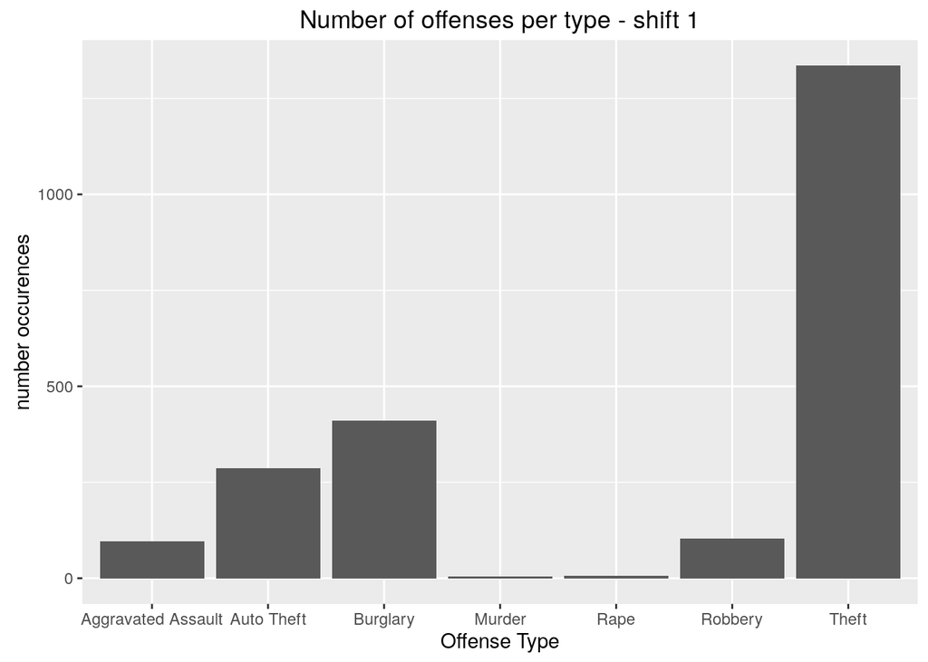

```r
ggplot(shift1, aes(x= shift1$Offense_Type)) +
  geom_bar()+
  ggtitle("Number of offenses per type - shift 1")+
  ylab("number occurences")+
  xlab("Offense Type")
```

```r
group_by(shift2[!is.na(shift2$Offense_Type),], Offense_Type) %>%
  summarise(counts= sum(n_offenses, na.rm=TRUE)) %>%
  arrange(desc(counts))
```

```
## # A tibble: 7 × 2
##         Offense_Type counts
##                <chr>  <dbl>
## 1              Theft   2546
## 2           Burglary    806
## 3         Auto Theft    412
## 4 Aggravated Assault    254
## 5            Robbery    249
## 6               Rape     25
## 7             Murder      5
```

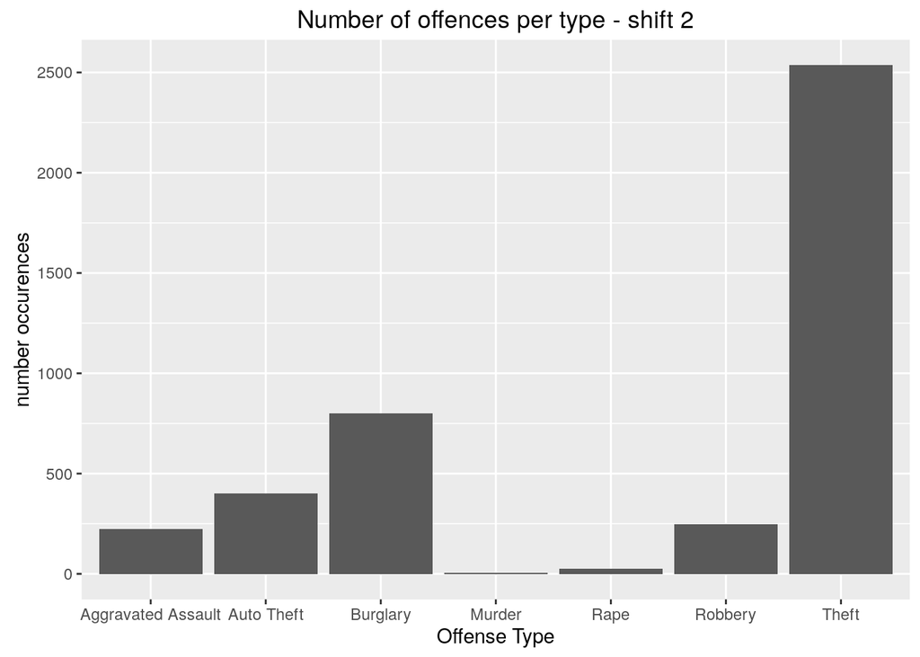

```r
ggplot(shift2, aes(x= shift2$Offense_Type)) +
  geom_bar()+
  ggtitle("Number of offences per type - shift 2")+
  ylab("number occurences")+
  xlab("Offense Type")
```

```r
group_by(shift3[!is.na(shift3$Offense_Type),], Offense_Type) %>%
  summarise(counts= sum(n_offenses, na.rm=TRUE)) %>%
  arrange(desc(counts))
```

```
## # A tibble: 7 × 2
##         Offense_Type counts
##                <chr>  <dbl>
## 1              Theft   1545
## 2           Burglary    593
## 3            Robbery    423
## 4         Auto Theft    413
## 5 Aggravated Assault    318
## 6               Rape     27
## 7             Murder     13
```

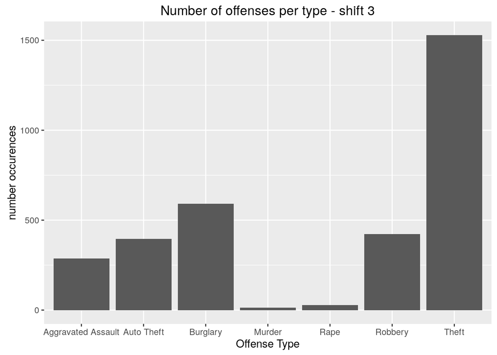

```r
ggplot(shift3, aes(x= shift3$Offense_Type)) +
  geom_bar()+
  ggtitle("Number of offenses per type - shift 3")+
  ylab("number occurences")+
  xlab("Offense Type")
```

Having made this analysis, we can extend it to an analysis of the weekdays, to see if there is a change during the days

```r
#general
group_by(policeData,wday)%>%summarise(counts=sum(n_offenses))%>%arrange(desc(counts))
```

```
## # A tibble: 7 × 2
##    wday counts
##   <ord>  <dbl>
## 1   Fri   1714
## 2 Thurs   1595
## 3   Sat   1566
## 4   Wed   1488
## 5   Mon   1464
## 6  Tues   1336
## 7   Sun   1254
```

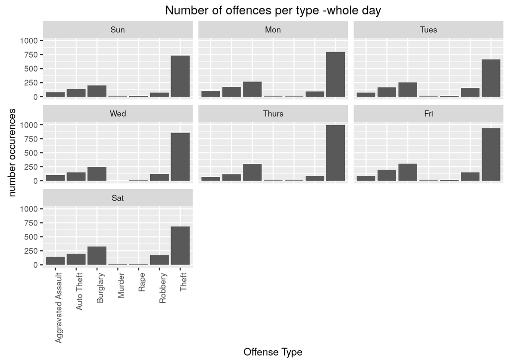

```r
ggplot(policeData, aes(x= policeData$Offense_Type)) +geom_bar()+
  ggtitle("Number of offences per type -whole day")+
  ylab("number occurences")+ xlab("Offense Type")+facet_wrap(~wday)+
  theme(text = element_text(size=10),axis.text.x = element_text(angle=90, hjust=1))
```

```r
#shift 1
group_by(shift1,day)%>%summarise(counts=sum(n_offenses))%>%arrange(desc(counts))
```

```
## # A tibble: 31 × 2
##      day counts
##    <int>  <dbl>
## 1     12     90
## 2     15     86
## 3     21     86
## 4     23     85
## 5     11     84
## 6     14     84
## 7      5     82
## 8     19     82
## 9      2     81
## 10    16     81
## # ... with 21 more rows
```

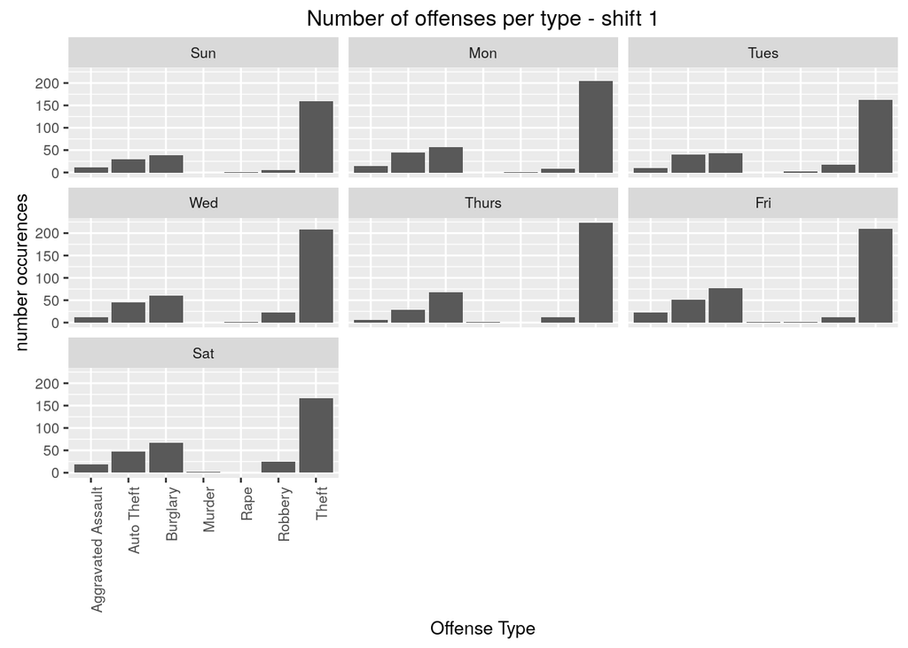

```r
ggplot(shift1, aes(x= shift1$Offense_Type)) +geom_bar()+
  ggtitle("Number of offenses per type - shift 1")+
  ylab("number occurences")+ xlab("Offense Type")+facet_wrap(~wday)+
  theme(text = element_text(size=10),axis.text.x = element_text(angle=90, hjust=1))
```

```r
#shift 2
group_by(shift2,day)%>%summarise(counts=sum(n_offenses))%>%arrange(desc(counts))
```

```
## # A tibble: 31 × 2
##      day counts
##    <int>  <dbl>
## 1     12    177
## 2      7    168
## 3      9    167
## 4      8    157
## 5     14    155
## 6      2    150
## 7     25    149
## 8     15    146
## 9      4    145
## 10    23    143
## # ... with 21 more rows
```

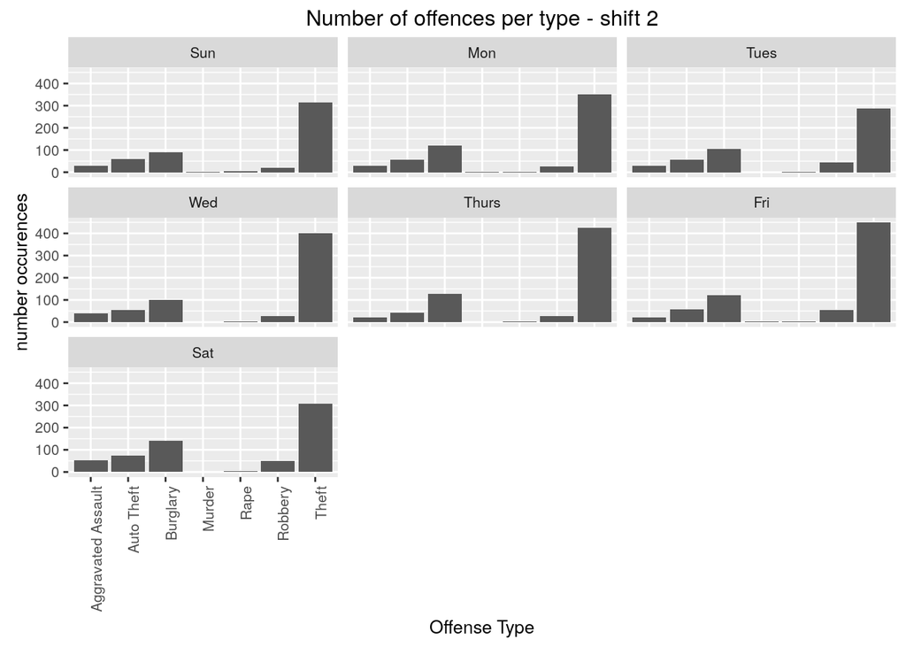

```r
ggplot(shift2, aes(x= shift2$Offense_Type)) +geom_bar()+
  ggtitle("Number of offences per type - shift 2")+
  ylab("number occurences")+ xlab("Offense Type")+facet_wrap(~wday)+
  theme(text = element_text(size=10),axis.text.x = element_text(angle=90, hjust=1))
```

```r
#shift 3
group_by(shift3,day)%>%summarise(counts=sum(n_offenses))%>%arrange(desc(counts))
```

```
## # A tibble: 31 × 2
##      day counts
##    <int>  <dbl>
## 1     20    153
## 2     26    131
## 3     14    121
## 4     18    120
## 5      7    118
## 6     15    116
## 7      3    115
## 8     23    115
## 9     12    113
## 10     2    112
## # ... with 21 more rows
```

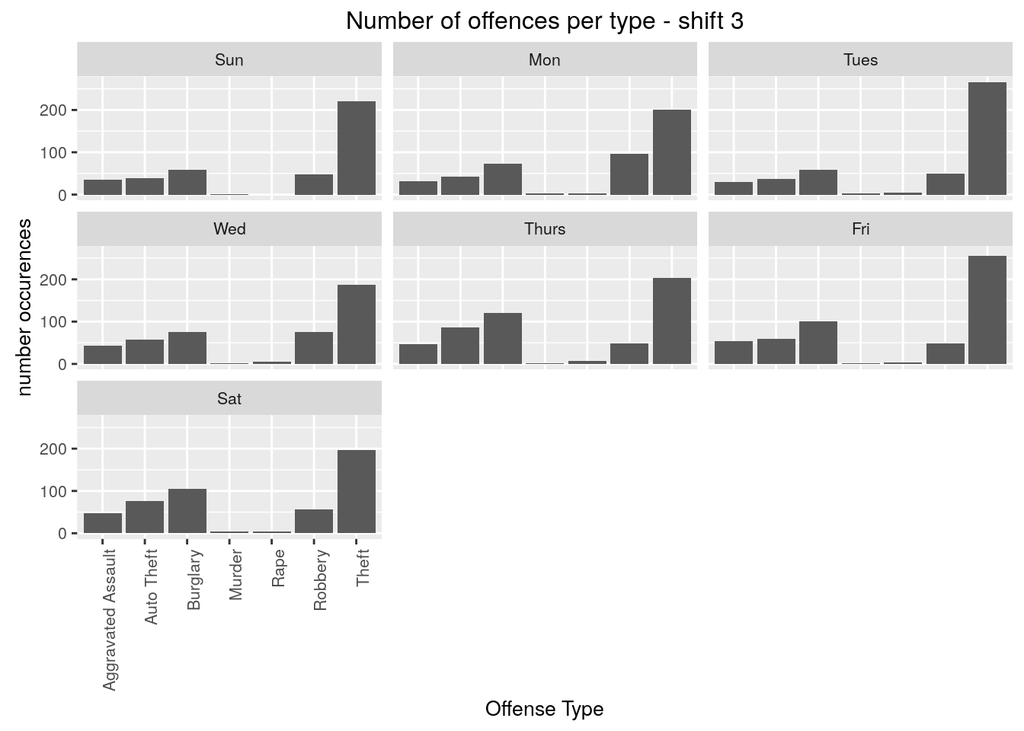

```r
ggplot(shift3, aes(x= shift3$Offense_Type)) +geom_bar()+
  ggtitle("Number of offences per type - shift 3")+
  ylab("number occurences")+ xlab("Offense Type")+facet_wrap(~wday)+
  theme(text = element_text(size=10),axis.text.x = element_text(angle=90, hjust=1))
```

# Third Part - Predictive Modeling

We start preparing the dataset that will be predicted.

First add the week day and cut the unuseful data. We group the data by beat, week day and hour, and calculate the average number of offenses per beat and weekday.

```r
policeData<-mutate(policeData,day=day(Date),wday=wday(Date,label=TRUE))
group_by(policeData, Beat, wday, Hour)%>%summarise(n_offenses=mean(n_offenses))
```

```
## Source: local data frame [7,012 x 4]
## Groups: Beat, wday [?]
##
##     Beat  wday  Hour n_offenses
##    <chr> <ord> <dbl>      <dbl>
## 1  10H10   Sun    13          1
## 2  10H10   Sun    16          1
## 3  10H10   Sun    20          1
## 4  10H10   Mon     1          1
## 5  10H10   Mon     5          1
## 6  10H10   Mon     9          1
## 7  10H10   Mon    13          1
## 8  10H10   Mon    19          1
## 9  10H10   Mon    22          1
## 10 10H10  Tues     0          1
## # ... with 7,002 more rows
```

Then add the shift which ocurred the offenses.

```r
policeDataTest$shift<-NA
policeDataTest$shift[policeDataTest$Hour>=8 & policeDataTest$Hour <12]<-"shift1"
policeDataTest$shift[policeDataTest$Hour>=12 & policeDataTest$Hour <19]<-"shift2"
policeDataTest$shift[policeDataTest$Hour>=19 & policeDataTest$Hour <24]<-"shift3"
policeDataTest$shift[policeDataTest$Hour>=0 & policeDataTest$Hour <8]<-"shift3"
```

Swapping the last two columns and cancel the information about the Hour

```r
policeDataTest<-policeDataTest[c("Beat","wday", "shift", "n_offenses")]
policeDataTest$Beat<-factor(policeDataTest$Beat)
policeDataTest$shift<-factor(policeDataTest$shift)
group_by(policeDataTest, Beat, wday, shift)%>%summarise(n_offenses=mean(n_offenses))
```

```
## Source: local data frame [2,107 x 4]
## Groups: Beat, wday [?]
##
##      Beat  wday  shift n_offenses
##    <fctr> <ord> <fctr>      <dbl>
## 1   10H10   Sun shift2          1
## 2   10H10   Sun shift3          1
## 3   10H10   Mon shift1          1
## 4   10H10   Mon shift2          1
## 5   10H10   Mon shift3          1
## 6   10H10  Tues shift1          1
## 7   10H10  Tues shift2          1
## 8   10H10  Tues shift3          1
## 9   10H10   Wed shift1          1
## 10  10H10   Wed shift2          1
## # ... with 2,097 more rows
```

Extract the samples for the training and test dataset.

```r
splitVal <- 0.7
set.seed(1234)
sample.tr <-sample(1:nrow(policeDataTest),as.integer(splitVal*nrow(policeDataTest)))
#train
policeDataTest[sample.tr, ]
```

```
## Source: local data frame [1,474 x 4]
## Groups: Beat, wday [732]
##
##      Beat  wday  shift n_offenses
##    <fctr> <ord> <fctr>      <dbl>
## 1   11H50   Sat shift2          1
## 2   24C20 Thurs shift2          1
## 3   23J50   Sun shift2          1
## 4   24C20   Fri shift2          1
## 5    6B60   Wed shift2          1
## 6   24C50   Sat shift1          1
## 7   10H20   Sun shift3          1
## 8   14D30   Wed shift1          1
## 9    2A30   Mon shift1          1
## 10   1A50   Wed shift1          1
## # ... with 1,464 more rows
```

```r
#test
policeDataTest[-sample.tr,]
```

```
## Source: local data frame [633 x 4]
## Groups: Beat, wday [458]
##
##      Beat  wday  shift n_offenses
##    <fctr> <ord> <fctr>      <dbl>
## 1   10H10   Mon shift3          1
## 2   10H10   Wed shift1          1
## 3   10H10   Wed shift2          1
## 4   10H10   Wed shift3          1
## 5   10H10 Thurs shift2          1
## 6   10H20   Sun shift1          1
## 7   10H20   Mon shift3          1
## 8   10H20   Wed shift1          1
## 9   10H20   Wed shift2          1
## 10  10H20   Wed shift3          1
## # ... with 623 more rows
```

Put at least one beat in the training and test dataset to equalize the factors of each dataset.

```r
set.seed(1234) # for reproduction
sample.tr <-sample(1:nrow(policeDataTest),as.integer(splitVal*nrow(policeDataTest)))
tr <- policeDataTest[sample.tr, ] #Split into two sets
ts <- policeDataTest[-sample.tr,]

Beats <- unique(policeDataTest$Beat)

updateT <- function(ts, BeatsTS) {
  result <- ts
  for (beat in BeatsTS)  {
    if (nrow(ts[ts$Beat == beat,]) == 0) {
      result <- rbind(result, policeDataTest[policeDataTest$Beat == beat,][1,])
    }
  }
  return(result)
}
tr <- updateT(tr, Beats)
ts <- updateT(ts, Beats)
```

Predict with Multiple Linear Regression.

```r
model_lm <- lm(n_offenses ~., tr)
model_lm_final <- step(model_lm)
preds_lm <- predict(model_lm_final, ts)
```

Predict with Tree Based Model

```r
model_tree <- rpartXse(n_offenses ~ .,tr)
preds_tree <- predict(model_tree,ts)
```

Predict with Support Vector Machines

```r
model_svm <- svm(n_offenses ~., tr)
preds_svm <- predict(model_svm,ts)
```

Predict with Neural Networks

```r
model_nn <- nnet(n_offenses ~., tr, size=5, decay=0.1, maxit=1000)
preds_nn <- predict(model_nn,ts)
```

Predict with Multivariate Adaptive Regression Splines

```r
model_mars <- earth(n_offenses ~., tr)
preds_mars <- predict(model_mars, ts)
```

Compute the errors of each prediction

Error of Multiple Linear Regression.

```r
regr.eval(ts$n_offenses, preds_lm, train.y=tr$n_offenses)
```

```
##        mae        mse       rmse       mape       nmse       nmae
## 0.02912261 0.00620759 0.07878826 0.02504347 1.00215704 0.99536049
```

Error of Tree Based Model

```r
regr.eval(ts$n_offenses, preds_tree, train.y=tr$n_offenses)
```

```
##         mae         mse        rmse        mape        nmse        nmae
## 0.029258354 0.006194229 0.078703426 0.025172536 1.000000000 1.000000000
```

Error of Support Vector Machines

```r
regr.eval(ts$n_offenses, preds_svm, train.y=tr$n_offenses)
```

```
##        mae        mse       rmse       mape       nmse       nmae
## 0.10310380 0.01312211 0.11455176 0.10002427 2.11844034 3.52390966
```

Error of Neural Networks

```r
regr.eval(ts$n_offenses, preds_nn, train.y=tr$n_offenses)
```

```
##         mae         mse        rmse        mape        nmse        nmae
## 0.022439405 0.006697059 0.081835560 0.018098879 1.081177103 0.766940103
```

Error of Multivariate Adaptive Regression Splines

```r
regr.eval(ts$n_offenses, preds_mars, train.y=tr$n_offenses)
```

```
##         mae         mse        rmse        mape        nmse        nmae
## 0.029906309 0.006352695 0.079703795 0.025869746 1.025582784 1.022145957
```

```r
timeTablePolice<-matrix(nrow=116*7*3, ncol=4)
beats=unique(policeDataTest$Beat)
days=unique(policeDataTest$wday)
shift=unique(policeDataTest$shift)
predi<-ts[1,]
predicted=0
c=0

for(i in 1:2436){

  timeTablePolice[i,1]= as.character(beats[ceiling(i/21)])
  predi$Beat=beats[ceiling(i/21)]

  c=ceiling(i/3)%%7
  if(c==0){timeTablePolice[i,2]=as.character(days[7])
  predi$wday=days[7]
  }
  else{
    timeTablePolice[i,2]=as.character(days[c])#ceiling(i/7)%%7#as.character(days[ceiling(i%%7])}
    predi$wday=days[c]
  }
  if(i%%3==0){
    timeTablePolice[i,3]=as.character(shift[3])
    predi$shift=shift[3]
  }else{
    timeTablePolice[i,3]=as.character(shift[i%%3])
    predi$shift=shift[i%%3]
  }

  predi$n_offenses=NA
  predicted<-predict(model_nn,predi)
  timeTablePolice[i,4]=predicted
}
summary(timeTablePolice)
```

```
##        V1           V2           V3                      V4
##  10H10  :  21   Fri  :348   shift1:812   0.993294649410554:   1
##  10H20  :  21   Mon  :348   shift2:812   0.993295311336557:   1
##  10H30  :  21   Sat  :348   shift3:812   0.993295648842468:   1
##  10H40  :  21   Sun  :348                0.993296588523234:   1
##  10H50  :  21   Thurs:348                0.993296657951079:   1
##  10H60  :  21   Tues :348                0.993297200919766:   1
##  (Other):2310   Wed  :348                (Other)          :2430
```